# **Business Problem Statement:**

Booking is trying to leverage its vast troves of data to understand the seasonal booking patterns of its customers. By predicting the seasonal demand for hotel bookings across various regions, Booking can optimize its inventory, adjust marketing strategies, and provide better recommendations to its users. The challenge here is to uncover these patterns and design strategies based on time series analysis.

## **Data Table:**

**Info_data**

| Column Name | Description | Feature Type |
| --- | --- | --- |
| booking_id | Unique ID for each booking | Categorical |
| hotel_id | Unique ID for each hotel | Categorical |
| user_id | Unique ID for each user | Categorical |
| booking_date | Date when the booking was made | Date |
| stay_date | Date when the user will stay at the hotel | Date |
| price | Price of the booking | Continuous |
| region | Region of the hotel | Categorical |
| rating | Rating of the hotel | Continuous |
| user_intent | Reason for booking (e.g. Leisure, Work) | Categorical |
| was_stayed | Indicates if the user stayed or not (0 = no, 1 = yes) | Binary |
| number_of_bookings | Estimated count of bookings for a given date in the Europe region | Continuous |

## **Questions:**

1. **Data Manipulation & Cleaning**:
   - *Scenario*: Often the same hotel gets booked for multiple dates by various users. To understand demand patterns, we need to aggregate the data not just by region but also by the purpose of the stay (`user_intent`).

   **Question**: Aggregate the booking data by `region` and `user_intent`. Calculate the total number of bookings and the average price for each group (region and user_intent combined). What are the top 5 groups (combinations of region and user_intent) by average booking price during the peak travel season (June - August)?
2. **Probability and Statistics**:
   - *Scenario*: Given the nature of hotel booking, there might be days with unusually high or low bookings which might be anomalies.

   **Question**: Using the bootstrap method, calculate the 95% confidence interval of the mean number of bookings for the month of December. Is the actual mean within this interval?
3. **Machine Learning & Modeling**:
   - *Scenario*: To aid in promotional activities, you decide to predict the number of bookings for a given 'stay_date' and 'region'.

   **Question**: Build a time series model to predict the number of bookings for the next 30 days in the "Europe" region. Specify which features you'd use and why. Also, explain how you would validate this model, ensuring that it's not overfitting.
4. **Product Design & Analytics**:
   - *Scenario*: One of the key features for users is the 'Value for Money' tag on hotel listings. This feature becomes even more crucial during peak seasons.

   **Question**: Design an algorithmic approach to automatically tag a hotel listing as 'Value for Money' during the peak season, considering factors like price, region, and rating. Explain how this will be beneficial in driving more bookings. Also, if you were to run an A/B test on this feature, how would you set it up and evaluate its success?

## Load Data

```python
import pandas as pd

Info_data = pd.read_csv('https://storage.googleapis.com/datalynn-datasets/interview-challenge/technology/Booking_Seasonal_Patterns/Booking_seasonal_patterns.csv')
```

## Question 1

**Data Manipulation & Cleaning**:

- **Scenario**: Often the same hotel gets booked for multiple dates by various users. To understand demand patterns, we need to aggregate the data not just by region but also by the purpose of the stay (`user_intent`).
- **Question**: Aggregate the booking data by `region` and `user_intent`. Calculate the total number of bookings and the average price for each group (region and user_intent combined). What are the top 5 groups (combinations of region and user_intent) by average booking price during the peak travel season (June - August)?

## Solution

### Hints:

1. **Data Manipulation & Cleaning**:
   - Check for missing values in `Info_data`.
   - Ensure appropriate data types for each column, especially for date, continuous, and binary columns.
2. **Aggregate Booking Data**:
   - Group data by `region` and `user_intent`.
   - Calculate the total number of bookings for each group.
   - Calculate the average price for each group.
3. **Analyze Peak Travel Season**:
   - Filter the data to only include bookings from June to August.
   - Sort by average booking price in descending order.
   - Extract the top 5 regions.

### Step 1: Data Manipulation & Cleaning:

```python
# Checking for missing values in Info_data
print(Info_data.isnull().sum())

# Checking data types
print(Info_data.dtypes)

# Convert stay_date column to datetime format if not already
if Info_data['stay_date'].dtype != 'datetime64[ns]':
    Info_data['stay_date'] = pd.to_datetime(Info_data['stay_date'])
```

```
booking_id            0
hotel_id              0
user_id               0
booking_date          0
stay_date             0
region                0
rating                0
user_intent           0
price                 0
number_of_bookings    0
was_stayed            0
dtype: int64
booking_id              int64
hotel_id                int64
user_id                 int64
booking_date           object
stay_date              object
region                 object
rating                float64
user_intent            object
price                   int64
number_of_bookings      int64
was_stayed              int64
dtype: object
```

### Step 2: Aggregate Booking Data:

```python
# Grouping by region and user_intent
grouped_data = Info_data.groupby(['region', 'user_intent']).agg({'booking_id': 'count',
                                                                'price': 'mean'}).reset_index()

# Rename columns for clarity
grouped_data.rename(columns={'booking_id': 'total_bookings', 'price': 'avg_price'}, inplace=True)

print(grouped_data.head())
```

```
      region user_intent  total_bookings   avg_price
0     Africa     Leisure             117  127.641026
1     Africa        Work             109  125.357798
2       Asia     Leisure              84  123.869048
3       Asia        Work              86  121.802326
4  Australia     Leisure             115  112.086957
```

### Step 3: Analyze Peak Travel Season:

```python
# Filter for peak travel season (June - August)
peak_season_data = Info_data[(Info_data['stay_date'].dt.month >= 6) &
                             (Info_data['stay_date'].dt.month <= 8)]

# Group by region and user_intent for peak season
peak_grouped_data = peak_season_data.groupby(['region', 'user_intent']).agg({'booking_id': 'count',
                                                                             'price': 'mean'}).reset_index()

# Rename the 'price' column to 'avg_price'
peak_grouped_data.rename(columns={'price': 'avg_price'}, inplace=True)

# Sort by average price in descending order and pick top 5 groups
top_groups = peak_grouped_data.sort_values(by='avg_price', ascending=False).head(5)

print(top_groups[['region', 'user_intent', 'avg_price']])
```

```
          region user_intent   avg_price
5      Australia        Work  139.791667
8  North America     Leisure  138.444444
7         Europe        Work  130.178571
2           Asia     Leisure  124.000000
6         Europe     Leisure  123.730769
```

This solution gives us the top 5 combinations of region and user_intent by average booking price during the peak travel season.

## Question 2

**Probability and Statistics**:

- **Scenario**: Given the nature of hotel booking, there might be days with unusually high or low bookings which might be anomalies.
- **Question**: Using the bootstrap method, calculate the 95% confidence interval of the mean number of bookings for the month of December. Is the actual mean within this interval?

## Solution

### Hints:

1. **Data Manipulation & Cleaning**:
   - Convert `booking_date` to datetime format if not already done.
   - Filter data for bookings made in December.
2. **Bootstrap**:
   - Draw bootstrap samples from the December booking data.
   - Calculate the mean for each sample.
   - Store all bootstrap sample means in an array.
3. **Calculate 95% Confidence Interval**:
   - Find the 2.5th percentile and the 97.5th percentile of the bootstrap sample means to get the confidence interval.
4. **Check Actual Mean**：
   - Calculate the actual mean of bookings in December.
   - Determine if this mean lies within the computed confidence interval.

### Step 1: Data Manipulation & Cleaning:

```python
# Convert booking_date to datetime format if not already
if Info_data['booking_date'].dtype != 'datetime64[ns]':
    Info_data['booking_date'] = pd.to_datetime(Info_data['booking_date'])

# Filter for December bookings
december_data = Info_data[Info_data['booking_date'].dt.month == 12]
```

### Step 2: Bootstrap:

Bootstrap involves drawing random samples with replacement from the data and then computing the statistic (mean, in this case) for each sample.

```python
import numpy as np

def bootstrap_sample(data, n_bootstrap):
    """Generate bootstrap samples from the data."""
    return np.random.choice(data, size=len(data), replace=True)

n_iterations = 10000
bootstrap_means = []

for _ in range(n_iterations):
    sample = bootstrap_sample(december_data['booking_id'], n_iterations)
    sample_mean = sample.mean()
    bootstrap_means.append(sample_mean)
```

### Step 3: Calculate 95% Confidence Interval:

```python
confidence_level = 0.95
lower_percentile = (1 - confidence_level) / 2 * 100
upper_percentile = (1 + confidence_level) / 2 * 100

confidence_interval = (np.percentile(bootstrap_means, lower_percentile),
                       np.percentile(bootstrap_means, upper_percentile))

print(f"95% Confidence Interval for Mean Bookings in December: {confidence_interval}")
```

```
95% Confidence Interval for Mean Bookings in December: (508.6505263157895, 617.6955263157895)
```

### Step 4: Check Actual Mean

```python
actual_mean = december_data['booking_id'].mean()

print(f"Actual Mean of Bookings in December: {actual_mean}")

if confidence_interval[0] <= actual_mean <= confidence_interval[1]:
    print("The actual mean lies within the 95% confidence interval.")
else:
    print("The actual mean does not lie within the 95% confidence interval.")
```

```
Actual Mean of Bookings in December: 564.2631578947369
The actual mean lies within the 95% confidence interval.
```

## Question 3

**Machine Learning & Modeling**:

- **Scenario**: To aid in promotional activities, you decide to predict the number of bookings for a given `stay_date` and `region`.
- **Question**: Build a time series model to predict the number of bookings for the next 30 days in the "Europe" region. Specify which features you'd use and why. Also, explain how you would validate this model, ensuring that it's not overfitting.

## Solution

### Hints:

1. **Data Manipulation & Cleaning**:
   - Convert the `stay_date` column to datetime format if not already done.
   - Filter the data for the "Europe" region.
   - Resample the data to daily frequency and aggregate the number of bookings.
2. **Feature Engineering:**:
   - Derive temporal features such as day of the week, is_weekend, is_holiday, etc.
   - Lag-based features: booking count from previous days.
   - Rolling statistical features: moving average of bookings.
3. **Model Building & Evaluation**:
   - Choose an appropriate time series model.
   - Split the data into a training set and a test set (time-based split).
4. **More about Model Validation & Overfitting Prevention**：
   - Time series cross-validation.
   - Regularization techniques.
   - Model complexity considerations.

### Step 1: Data Manipulation & Cleaning:

```python
# Convert 'stay_date' to datetime
Info_data['stay_date'] = pd.to_datetime(Info_data['stay_date'])

# 1. Data Manipulation & Cleaning:
# Filtering data for the "Europe" region
df_europe = Info_data[Info_data['region'] == 'Europe']

# Aggregating data to get daily total bookings for Europe
df_europe_daily = df_europe.groupby('stay_date')['number_of_bookings'].sum().reset_index()

print(df_europe_daily.head())
```

```
            stay_date  number_of_bookings
0 2022-09-11 21:15:00                  95
1 2022-09-15 17:17:00                  46
2 2022-09-18 05:38:00                  70
3 2022-09-21 19:58:00                  50
4 2022-09-22 10:07:00                  10
```

### Step 2: Feature Engineering:

Temporal and lag-based features can help the model learn patterns and seasonality from the data.

```python
import numpy as np

# Creating lags
for i in range(1, 4):  # Creating 3 lags
    df_europe_daily[f'lag_{i}'] = df_europe_daily['number_of_bookings'].shift(i)

# Creating rolling features
df_europe_daily['rolling_mean_7'] = df_europe_daily['number_of_bookings'].rolling(window=7).mean()
df_europe_daily['rolling_std_7'] = df_europe_daily['number_of_bookings'].rolling(window=7).std()

# Extracting date features
df_europe_daily['day_of_week'] = df_europe_daily['stay_date'].dt.dayofweek
df_europe_daily['month'] = df_europe_daily['stay_date'].dt.month
df_europe_daily['quarter'] = df_europe_daily['stay_date'].dt.quarter

# Representing day_of_week and month as cyclical features
df_europe_daily['week_sin'] = np.sin(2 * np.pi * df_europe_daily['day_of_week'] / 7)
df_europe_daily['week_cos'] = np.cos(2 * np.pi * df_europe_daily['day_of_week'] / 7)
df_europe_daily['month_sin'] = np.sin(2 * np.pi * df_europe_daily['month'] / 12)
df_europe_daily['month_cos'] = np.cos(2 * np.pi * df_europe_daily['month'] / 12)


# Remove NaN values generated due to rolling features and lags
df_europe_daily.dropna(inplace=True)

# Log transformation
df_europe_daily['log_bookings'] = np.log1p(df_europe_daily['number_of_bookings'])
df_europe_daily.dropna(inplace=True)

# Splitting the dataset
train = df_europe_daily.iloc[:-30]
test = df_europe_daily.iloc[-30:]
```

### Step 3: Model Building:

ARIMA is a classic choice for univariate time series forecasting, but given you've generated multiple features, let's consider using SARIMAX (Seasonal ARIMA with eXogenous variables). This model will allow us to use the additional features.

```python
from statsmodels.tsa.statespace.sarimax import SARIMAX
from sklearn.metrics import mean_absolute_error, mean_squared_error
import warnings
warnings.filterwarnings('ignore')

# Train the SARIMAX model
# Modeling
features = ['lag_1', 'lag_2', 'lag_3', 'rolling_mean_7', 'rolling_std_7', 'week_sin', 'week_cos', 'month_sin', 'month_cos']
model = SARIMAX(train['log_bookings'], exog=train[features], order=(1,1,1), seasonal_order=(1,1,1,12))
results = model.fit(disp=False)

# Forecasting
forecast_log = results.get_forecast(steps=30, exog=test[features]).predicted_mean
forecast = np.expm1(forecast_log)  # inverse of log transformation
```

```python
# Evaluation:
mae = mean_absolute_error(test['number_of_bookings'], forecast)
mse = mean_squared_error(test['number_of_bookings'], forecast)
rmse = np.sqrt(mse)

print(f"Mean Absolute Error (MAE): {mae:.2f}")
print(f"Mean Squared Error (MSE): {mse:.2f}")
print(f"Root Mean Squared Error (RMSE): {rmse:.2f}")
```

```
Mean Absolute Error (MAE): 26.35
Mean Squared Error (MSE): 1021.57
Root Mean Squared Error (RMSE): 31.96
```

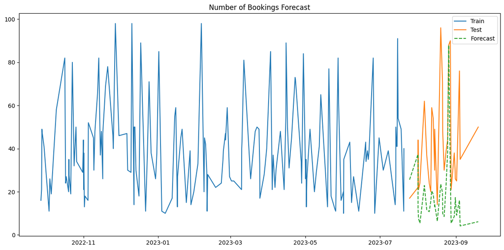

```python
import matplotlib.pyplot as plt
# Visual representation for validation
plt.figure(figsize=(15,7))
plt.plot(train['stay_date'], train['number_of_bookings'], label='Train')
plt.plot(test['stay_date'], test['number_of_bookings'], label='Test')
plt.plot(test['stay_date'], forecast, label='Forecast', linestyle='--')
plt.legend(loc='best')
plt.title('Number of Bookings Forecast')
plt.show()
```

### Step 4: More about Model Validation & Overfitting Prevention：

**Time Series Cross-Validation**: Instead of a simple train-test split, we can use TimeSeriesSplit from scikit-learn for cross-validation. This will give us a better idea of the model's robustness.

**Regularization**: For models that support regularization (like LASSO for linear regression or dropout for LSTMs), this can be applied.

**Model Complexity**: Given the vast number of features, tree-based models might provide better insights and interpretability. You can visualize feature importance to see which features have the most predictive power.

**Comparison with a Naive Model**: Compare the model's performance with a naive or simpler model. If the complex model isn't significantly better, it might be overfitting.

**Residual Analysis**: Analyze the residuals. They should ideally be white noise. Patterns in residuals indicate that the model has missed underlying patterns.

## Question 4

**Product Design & Analytics**:

- **Scenario**: One of the key features for users is the 'Value for Money' tag on hotel listings. This feature becomes even more crucial during peak seasons.
- **Question**: Design an algorithmic approach to automatically tag a hotel listing as 'Value for Money' during the peak season, considering factors like price, region, and rating. Explain how this will be beneficial in driving more bookings. Also, if you were to run an A/B test on this feature, how would you set it up and evaluate its success?

## Solution

### Hints:

1. **Data Exploration**:
   - Explore the distribution of price, region, and rating.
   - Analyze the seasonal trends using the `booking_date` and `stay_date`.
2. **Feature Engineering**:
   - Create a new feature for peak season based on the number of bookings. If the `number_of_bookings` is above a certain threshold, label it as peak season.
   - Create a metric to gauge 'Value for Money' combining price and rating.
3. **Design Algorithm for 'Value for Money'**:
   - Based on the price, rating, and region, create an algorithm to compute 'Value for Money' score for each hotel.
4. **A/B Testing**:
   - Lay out the procedure for A/B testing for this new feature.
5. **Benefits and Evaluation**:
   - Discuss potential benefits of this new feature.
   - How to measure the success of this feature using the available data.

### Step 1: Data Exploration:

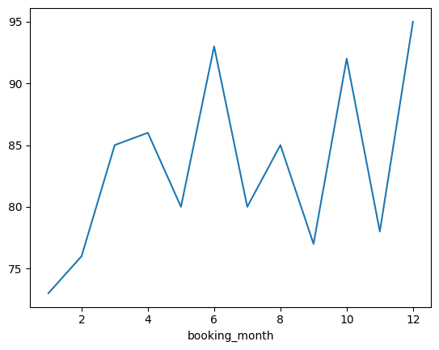

```python
# Checking data distribution
Info_data[['price', 'region', 'rating']].describe()

# Seasonal trend for booking
Info_data['booking_month'] = Info_data['booking_date'].dt.month
monthly_bookings = Info_data.groupby('booking_month')['booking_id'].count()
monthly_bookings.plot()
```

**Comments**:

Understand the distribution of prices, ratings, and bookings per month. Look for months with particularly high bookings to identify peak seasons.

### Step 2: Feature Engineering:

To ascertain the peak season:

```python
# Ascertain peak season
peak_threshold = Info_data['number_of_bookings'].quantile(0.75)  # Using the 75th percentile as threshold
Info_data['is_peak'] = Info_data['number_of_bookings'] > peak_threshold

# Metric for 'Value for Money'
Info_data['value_metric'] = Info_data['rating'] / Info_data['price']

# Displaying the first few rows to inspect our new columns
print(Info_data[['booking_id', 'is_peak', 'value_metric']].head())
```

```
   booking_id  is_peak  value_metric
0           1    False      0.053846
1           2    False      0.038835
2           3    False      0.033113
3           4    False      0.020408
4           5    False      0.098039
```

### Step 3: Design Algorithm for 'Value for Money':

We'll create an algorithm to determine whether each hotel should be tagged as 'Value for Money' during peak season.

```python
def tag_value_for_money(row):
    region_multiplier = {
        'Europe': 1.2,
        # Other regions can be added with respective multipliers based on their average prices and ratings
    }

    score = row['value_metric'] * region_multiplier.get(row['region'], 1)
    some_threshold = 0.2  # Hypothetical threshold, this should be determined by business logic or further analysis
    if row['is_peak'] and score > some_threshold:
        return 1
    return 0

Info_data['value_for_money'] = Info_data.apply(tag_value_for_money, axis=1)

# Displaying the first few rows to inspect the 'Value for Money' tag
print(Info_data[['booking_id', 'region', 'is_peak', 'value_metric', 'value_for_money']].head())
```

```
   booking_id     region  is_peak  value_metric  value_for_money
0           1     Europe    False      0.053846                0
1           2     Africa    False      0.038835                0
2           3     Europe    False      0.033113                0
3           4  Australia    False      0.020408                0
4           5  Australia    False      0.098039                0
```

### Step 4: A/B Testing:

**Grouping:**

- Group A (control group): Users who do not see the 'Value for Money' tag.
- Group B (experimental group): Users who see the 'Value for Money' tag.

**Duration:**

- Depending on the traffic, run the test for a sufficient duration to ensure statistical significance, perhaps 2-4 weeks.

**Evaluation Metrics:**

- Primary: Conversion rate (how many see the tag and then proceed with the booking).
- Secondary: User engagement metrics like time spent, reviews read, and other related actions.

```
# Hypothetical pseudo-code for analysis after the test:
conversion_A = group_A[group_A['was_stayed'] == 1].shape[0] / group_A.shape[0]
conversion_B = group_B[group_B['was_stayed'] == 1].shape[0] / group_B.shape[0]
```

**Comments:**

If conversion_B significantly exceeds conversion_A, this suggests that the 'Value for Money' tag is effective.

### Step 5: Benefits and Evaluation:

**1. Benefits:**

- **Increased Transparency**: The tag could help users quickly identify hotels that offer good value, thereby reducing the time spent on searching.
- **Boosted Trust**: Such tags can enhance user trust in the platform, ensuring that they're getting the best deals.
- **Higher Conversion Rates**: With a clearer sense of value, users may be more inclined to finalize their bookings.

**2. Evaluation:**

- Track the metrics discussed in the A/B test.
- Monitor feedback and reviews from users to understand qualitative feedback on the new feature.

**Final Comments:** The 'Value for Money' tag can be a powerful tool during peak seasons when customers are looking for the best deals. However, it's crucial to ensure the algorithm used to determine this tag is robust, fair, and transparent. The success of this feature hinges not just on higher conversion rates, but also on maintaining user trust and satisfaction.